# **Unsupervised Learning Project: AllLife Bank Customer Segmentation**

# **Marks: 30**

Welcome to the project on Unsupervised Learning. We will be using **Credit Card Customer Data** for this project.

## **Context**

**AllLife Bank wants to focus on its credit card customer base** in the next financial year. They have been advised by their marketing research team, that the penetration in the market can be improved. Based on this input, the marketing team proposes to run personalized campaigns to target new customers as well as upsell to existing customers.

Another insight from the market research was that the customers perceive the support services of the bank poorly. Based on this, the operations team wants to upgrade the service delivery model, to ensure that customers' queries are resolved faster. The head of marketing and the head of delivery, both decide to reach out to the Data Science team for help.

## **Objective**

**Identify different segments in the existing customer base**, taking into account their spending patterns as well as past interactions with the bank.

## **About the data**

Data is available on customers of the bank with their credit limit, the total number of credit cards the customer has, and different channels through which the customer has contacted the bank for any queries. These different channels include visiting the bank, online, and through a call center.

- **Sl_no** - Customer Serial Number
- **Customer Key** - Customer identification
- **Avg_Credit_Limit** - Average credit limit (currency is not specified, you can make an assumption around this)
- **Total_Credit_Cards** - Total number of credit cards
- **Total_visits_bank** - Total bank visits
- **Total_visits_online** - Total online visits
- **Total_calls_made** - Total calls made

## **Importing libraries and overview of the dataset**

**Note:** Please make sure you have installed the sklearn_extra library before running the below cell. If you have not installed the library, please run the below code to install the library:

!pip install scikit-learn-extra

```python
# Libraries to help with reading and manipulating data
import numpy as np
import pandas as pd

# Libraries to help with data visualization
import matplotlib.pyplot as plt
import seaborn as sns

sns.set_theme(style='darkgrid')

# Removes the limit for the number of displayed columns
pd.set_option("display.max_columns", None)
# Sets the limit for the number of displayed rows
pd.set_option("display.max_rows", 200)

# To scale the data using z-score
from sklearn.preprocessing import StandardScaler

# To compute distances
from scipy.spatial.distance import cdist, pdist

# To perform K-Means clustering and compute silhouette scores
from setuptools._distutils.version import LooseVersion
from sklearn.cluster import KMeans
from sklearn.metrics import silhouette_score


# To import DBSCAN and Gaussian Mixture
from sklearn.cluster import DBSCAN
from sklearn.mixture import GaussianMixture


# To perform hierarchical clustering, compute cophenetic correlation, and create dendrograms
from sklearn.cluster import AgglomerativeClustering
from scipy.cluster.hierarchy import dendrogram, linkage, cophenet

import warnings
warnings.filterwarnings("ignore")
```

### **Loading the data**

```python
# Specify the path to your CSV file
file_path = '/Users/naazafreen/Desktop/Data Sciencelearning MIT Program/Credit Card Customer Data.xlsx'

# Load the CSV file into a DataFrame
df = pd.read_excel(file_path)

# Set pandas option to display all columns in one line
pd.set_option('display.max_columns', None)  # Show all columns
pd.set_option('display.expand_frame_repr', False)  # Prevent line breaks
```

### **Data Overview**

- Observations
- Sanity checks

**Purpose: This is the process of exploring and getting familiar with the dataset.**

```python
# Display the first few rows in a single line
print("First few rows:")
print(df.head())

# shape function returns the number of rows and columns in the dataset.
print(" Total number of rows and columns:")
df.shape
```

```
First few rows:
   Sl_No  Customer Key  Avg_Credit_Limit  Total_Credit_Cards  Total_visits_bank  Total_visits_online  Total_calls_made
0      1         87073            100000                   2                  1                    1                 0
1      2         38414             50000                   3                  0                   10                 9
2      3         17341             50000                   7                  1                    3                 4
3      4         40496             30000                   5                  1                    1                 4
4      5         47437            100000                   6                  0                   12                 3
 Total number of rows and columns:
```

```
(660, 7)
```

```python
print("The datatypes of the different columns in the dataset are as follows:")
df.dtypes
```

```
The datatypes of the different columns in the dataset are as follows:
```

```
Sl_No                  int64
Customer Key           int64
Avg_Credit_Limit       int64
Total_Credit_Cards     int64
Total_visits_bank      int64
Total_visits_online    int64
Total_calls_made       int64
dtype: object
```

**Observation**

- The AllLife Bank dataset contains 660 rows and 7 numerical columns.

#### **Sanity checks :**

- Purpose: This is a process of validating the dataset to ensure it is logical,consistent, and usable.

Actions:

- Checking for the missing and null values.
- Ensuring the datatype of the columns are appropiate.
- checking for duplicates and inconsistent entries.

```python
print("\nMissing Values:")
print(df.isnull().sum())
```

```
Missing Values:
Sl_No                  0
Customer Key           0
Avg_Credit_Limit       0
Total_Credit_Cards     0
Total_visits_bank      0
Total_visits_online    0
Total_calls_made       0
dtype: int64
```

```python
print("\n Data Info:")
print(df.info())
```

```
 Data Info:
<class 'pandas.core.frame.DataFrame'>
RangeIndex: 660 entries, 0 to 659
Data columns (total 7 columns):
 #   Column               Non-Null Count  Dtype
---  ------               --------------  -----
 0   Sl_No                660 non-null    int64
 1   Customer Key         660 non-null    int64
 2   Avg_Credit_Limit     660 non-null    int64
 3   Total_Credit_Cards   660 non-null    int64
 4   Total_visits_bank    660 non-null    int64
 5   Total_visits_online  660 non-null    int64
 6   Total_calls_made     660 non-null    int64
dtypes: int64(7)
memory usage: 36.2 KB
None
```

```python
# Check for number of unique customer in the dataset.
print("\n No of Unique Customer :")
df['Customer Key'].nunique()
df['Customer Key'].value_counts()
```

```
 No of Unique Customer :
```

```
Customer Key
97935    2
50706    2
47437    2
37252    2
96929    2
        ..
73811    1
72892    1
51773    1
96163    1
80150    1
Name: count, Length: 655, dtype: int64
```

#### **Observation:**

**Duplicate Customer Keys:**

There are 660 total rows in your dataset, but only 655 unique customer keys. This means that 5 customer keys are duplicated (i.e., there are multiple rows for these customers).

**Many reasons for duplication can be as follows:**

- Multiple Interactions: Customers could have had multiple interactions with the bank (different visits, calls, or transactions) over time, leading to multiple records.
- Data Entry Issues: There could be inconsistencies in how customer data is recorded, leading to duplicate entries.
- Partial Data: Some duplicates might be partial (i.e., some columns have identical data, while others differ).
- Data Aggregation Problem: If the dataset was collected from multiple sources (e.g., call center, online banking), some customers may have been recorded more than once.

**We will Rectify the Issue of the Duplicate Customer Keys, as its a critical columns and it could hinder analysis if not handled properly.**

```python
# Check rows with duplicate customer keys
duplicate_entries = df[df['Customer Key'].duplicated(keep=False)]
print(duplicate_entries.sort_values(by='Customer Key'))
```

```
     Sl_No  Customer Key  Avg_Credit_Limit  Total_Credit_Cards  Total_visits_bank  Total_visits_online  Total_calls_made
48      49         37252              6000                   4                  0                    2                 8
432    433         37252             59000                   6                  2                    1                 2
4        5         47437            100000                   6                  0                   12                 3
332    333         47437             17000                   7                  3                    1                 0
411    412         50706             44000                   4                  5                    0                 2
541    542         50706             60000                   7                  5                    2                 2
391    392         96929             13000                   4                  5                    0                 0
398    399         96929             67000                   6                  2                    2                 2
104    105         97935             17000                   2                  1                    2                10
632    633         97935            187000                   7                  1                    7                 0
```

**Observation from the Duplicate Customer Key Analysis:**

- None of the rows with duplicate customer keys are completely identical, so there is no need to drop or delete any data points or rows.
- The differences in duplicate records are primarily related to the number of credit cards, total visits to the bank, calls to customer care, or online visits related to bank transactions. To address this, I will aggregate the data for these customers.
- Aggregating the data will allow us to consolidate customer information. For example, summing the visits for customers who have multiple records will give us a complete view of their total interactions with the bank. Similarly, averaging the credit limit will provide a more accurate estimate of the customer’s overall financial standing.

```python
# Aggregating data for duplicate customer keys
df_aggregated = df.groupby('Customer Key').agg({
    'Avg_Credit_Limit': 'mean',         # Take average of credit limits
    'Total_Credit_Cards': 'mean',       # Take average of credit cards
    'Total_visits_bank': 'sum',         # Sum bank visits
    'Total_visits_online': 'sum',       # Sum online visits
    'Total_calls_made': 'sum'           # Sum calls made
}).reset_index()

# Convert Total_Credit_Cards to integer after rounding
df_aggregated['Total_Credit_Cards'] = df_aggregated['Total_Credit_Cards'].round().astype(int)

print("Final shape after aggregation:", df_aggregated.shape)
```

```
Final shape after aggregation: (655, 6)
```

```python
# Reassign df_aggregated to df
df = df_aggregated
```

```python
# Pull data for a single customer with Customer Key 37252
# List of customer keys to filter
customer_ids = [37252, 50706, 47437,97935]

# Pull data for multiple customers
multiple_customers_data = df[df['Customer Key'].isin(customer_ids)]

# Display the data for the selected customers
print(multiple_customers_data)
```

```
     Customer Key  Avg_Credit_Limit  Total_Credit_Cards  Total_visits_bank  Total_visits_online  Total_calls_made
193         37252           32500.0                   5                  2                    3                10
269         47437           58500.0                   6                  3                   13                 3
296         50706           52000.0                   6                 10                    2                 4
638         97935          102000.0                   4                  2                    9                10
```

```python
# Check for missing data
missing_data = df.isnull().sum()
print(missing_data)
```

```
Customer Key           0
Avg_Credit_Limit       0
Total_Credit_Cards     0
Total_visits_bank      0
Total_visits_online    0
Total_calls_made       0
dtype: int64
```

#### *Perform a Final Sanity Check*

```python
# Check final shape and uniqueness of customer keys
print("Final shape:", df.shape)
print("Number of unique customer keys:", df['Customer Key'].nunique())

# Check for any remaining duplicate customer keys
print("Number of duplicate customer keys:", df.duplicated(subset='Customer Key').sum())
```

```
Final shape: (655, 6)
Number of unique customer keys: 655
Number of duplicate customer keys: 0
```

```python
df.head()
```

|  | Customer Key | Avg_Credit_Limit | Total_Credit_Cards | Total_visits_bank | Total_visits_online | Total_calls_made |
| --- | --- | --- | --- | --- | --- | --- |
| 0 | 11265 | 51000.0 | 7 | 3 | 2 | 0 |
| 1 | 11398 | 12000.0 | 6 | 5 | 2 | 1 |
| 2 | 11412 | 19000.0 | 2 | 2 | 3 | 4 |
| 3 | 11466 | 9000.0 | 7 | 5 | 0 | 0 |
| 4 | 11562 | 38000.0 | 4 | 3 | 2 | 0 |

#### **Final Observation:**

- **Duplicates Resolved**: After addressing the duplicates, the number of unique customer keys now matches the number of rows, ensuring there are no duplicate entries.
- **Missing Data Check**: No missing data was found in the dataset.
- **Serial Number Dropped**: The serial number column will be dropped from the clean data. Since the data has been aggregated and multiple rows for each customer have been merged into a single row, the serial number is no longer necessary. The **Customer Key** will serve as the primary identifier going forward.

## **Data Preprocessing and Exploratory Data Analysis**

- EDA is an important part of any project involving data.
- It is important to investigate and understand the data better before building a model with it.
- A few questions have been mentioned below which will help you approach the analysis in the right manner and generate insights from the data.
- A thorough analysis of the data, in addition to the questions mentioned below, should be done.
- Check and drop the duplicate customer keys
- Drop the variables that are not required for the analysis
- Check duplicate rows and remove them.

**Questions:**

1. How does the distribution and outliers look for each variable in the data?
2. How are the variables correlated with each other?

#### **Check the summary Statistics**

```python
# 1. Descriptive Statistics

df.describe().T
```

|  | count | mean | std | min | 25% | 50% | 75% | max |
| --- | --- | --- | --- | --- | --- | --- | --- | --- |
| Customer Key | 655.0 | 55058.158779 | 25606.965469 | 11265.0 | 33623.5 | 53898.0 | 77084.5 | 99843.0 |
| Avg_Credit_Limit | 655.0 | 34403.053435 | 37231.630815 | 3000.0 | 10000.0 | 18000.0 | 48000.0 | 200000.0 |
| Total_Credit_Cards | 655.0 | 4.700763 | 2.167084 | 1.0 | 3.0 | 5.0 | 6.0 | 10.0 |
| Total_visits_bank | 655.0 | 2.421374 | 1.657944 | 0.0 | 1.0 | 2.0 | 4.0 | 10.0 |
| Total_visits_online | 655.0 | 2.625954 | 2.952571 | 0.0 | 1.0 | 2.0 | 4.0 | 15.0 |
| Total_calls_made | 655.0 | 3.610687 | 2.869678 | 0.0 | 1.0 | 3.0 | 5.0 | 10.0 |

#### **Key Insights:**

- Avg_Credit_Limit shows a significant variation, with a few customers having very high credit limits, which skews the data.
- Total_Credit_Cards: Most customers hold between 3 to 6 cards, with a small portion holding up to 10 cards.
- Bank and Online Visits: Both show a similar pattern where half of the customers make 2 or fewer visits. However, the high maximum values indicate that a small subset of customers engages frequently either in person or online.
- Total_calls_made: The majority of customers make 3 or fewer calls, but some customers make up to 10 calls, indicating potential dissatisfaction or complex issues that require frequent contact with customer support.

**These insights suggest that the bank has a diverse customer base, with varying degrees of interaction across different channels (bank visits, online, calls). This information could be useful for segmenting customers and personalizing service delivery or marketing strategies.**

```python
# For the distribution and outliers we will look for each variable in the data, we will utilize box plots and histograms to visualize key numerical data.

# Function to plot a boxplot and a histogram along the same scale

def histogram_boxplot(data, feature, figsize = (12, 7), kde = False, bins = None):

    """
    Boxplot and histogram combined

    data: dataframe
    feature: dataframe column
    figsize: size of figure (default (12, 7))
    kde: whether to the show density curve (default False)
    bins: number of bins for histogram (default None)
    """

    f2, (ax_box2, ax_hist2) = plt.subplots(
        nrows = 2,      # Number of rows of the subplot grid = 2
        sharex = True,  # X-axis will be shared among all subplots
        gridspec_kw = {"height_ratios": (0.25, 0.75)},
        figsize = figsize,
    )  # Creating the 2 subplots
    sns.boxplot(
        data = data, x = feature, ax = ax_box2, showmeans = True, color = "violet"
    )  # Boxplot will be created and a star will indicate the mean value of the column
    sns.histplot(
        data = data, x = feature, kde = kde, ax = ax_hist2, bins = bins
    ) if bins else sns.histplot(
        data = data, x = feature, kde = kde, ax = ax_hist2
    )  # For histogram
    ax_hist2.axvline(
        data[feature].mean(), color = "green", linestyle = "--"
    )  # Add mean to the histogram
    ax_hist2.axvline(
        data[feature].median(), color = "black", linestyle = "-"
    )  # Add median to the histogram
```

```
Plotting for Customer Key
Plotting for Avg_Credit_Limit
Plotting for Total_Credit_Cards
Plotting for Total_visits_bank
Plotting for Total_visits_online
Plotting for Total_calls_made
```

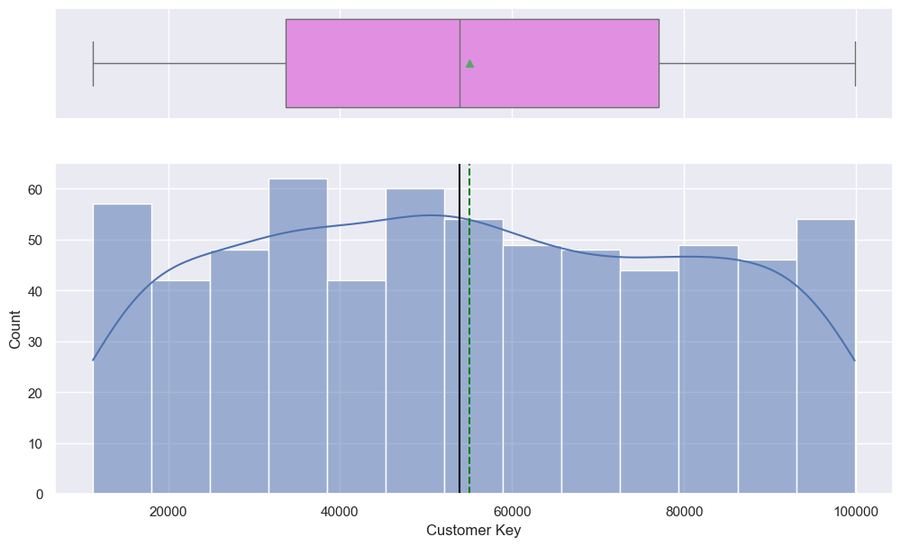

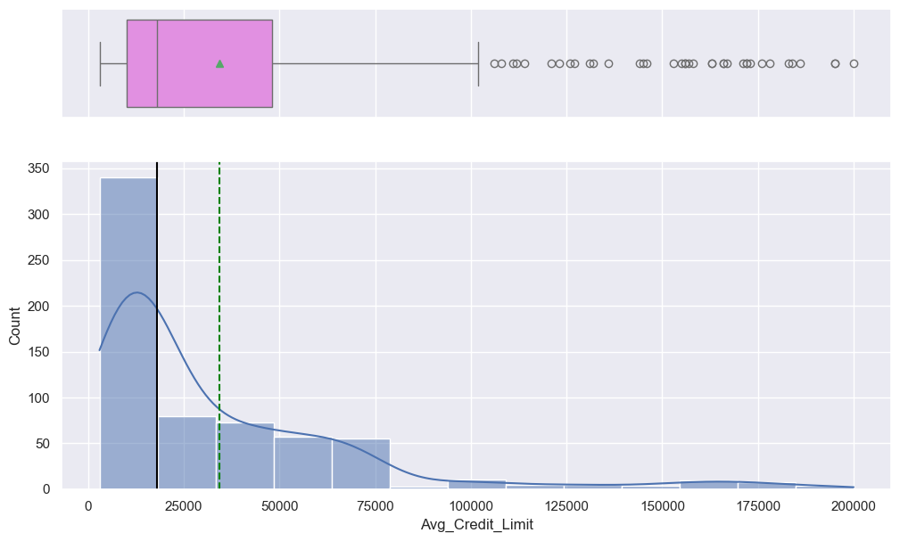

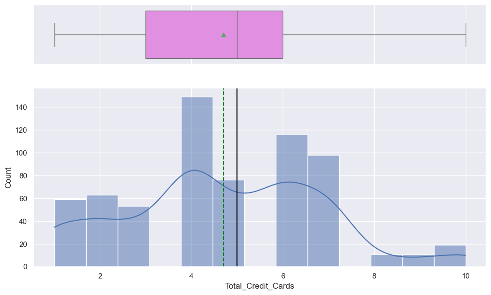

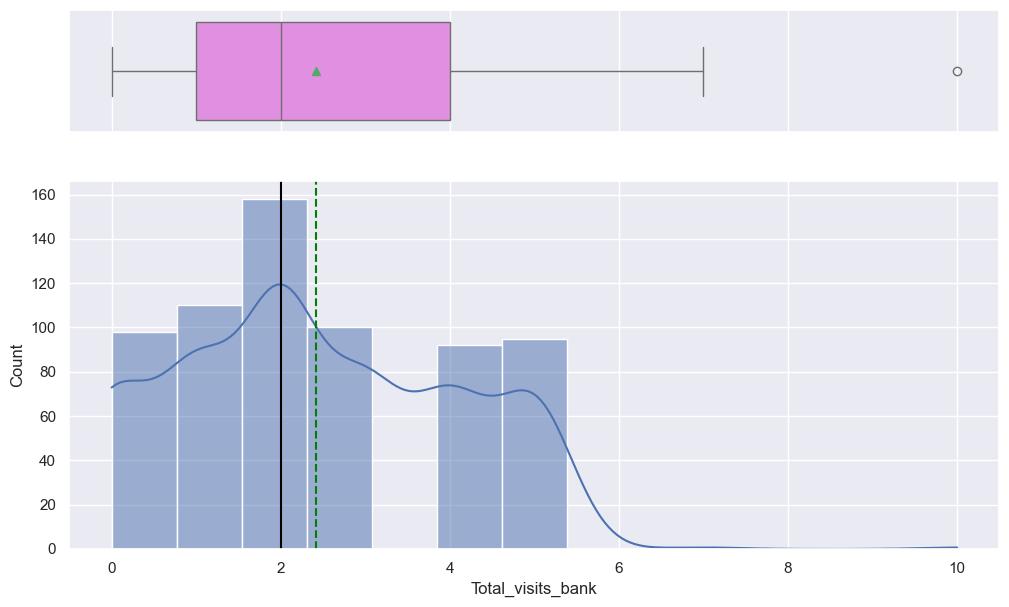

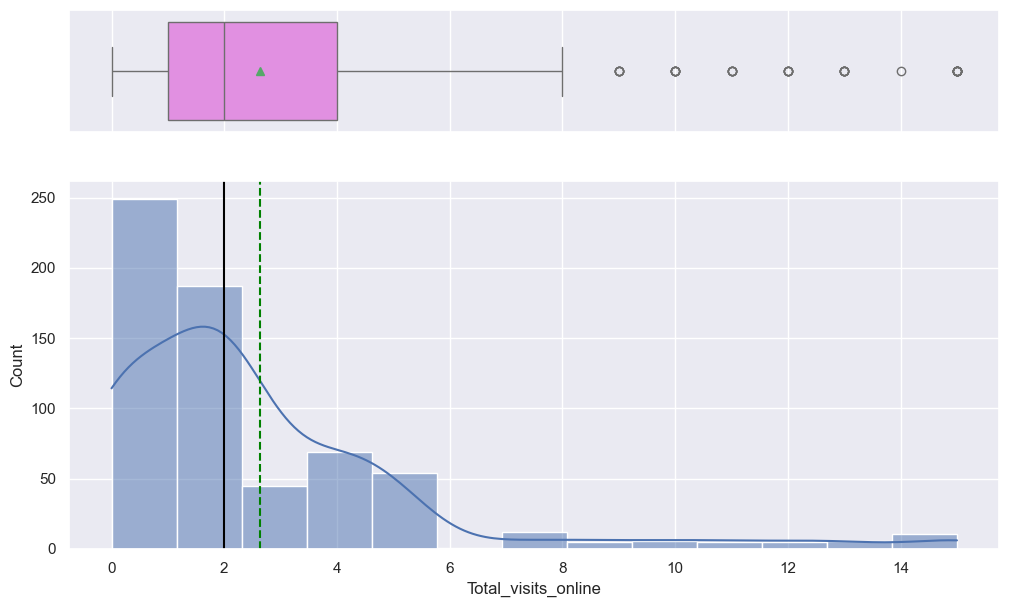

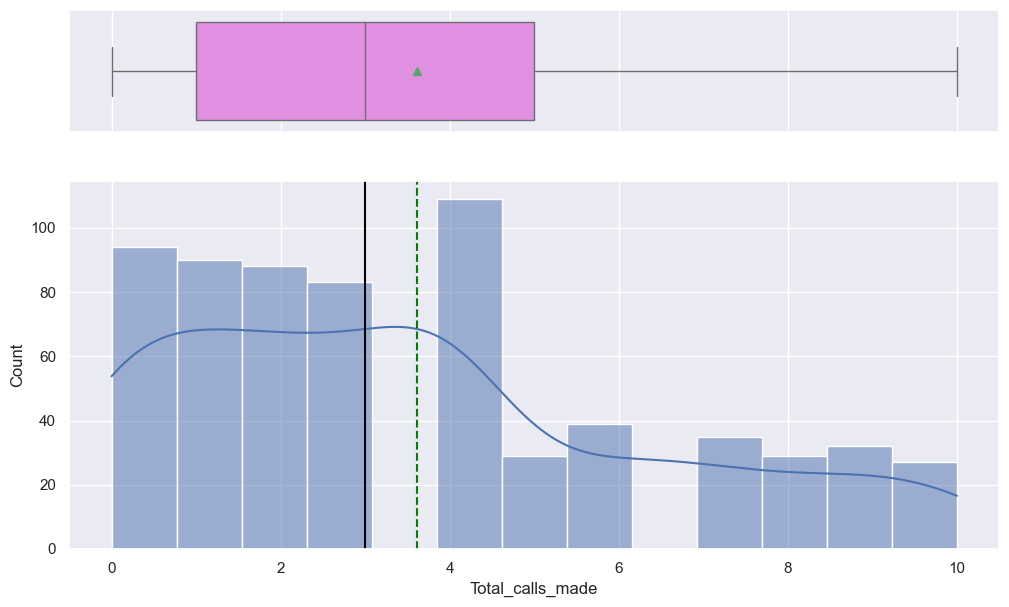

```python
# Calling the histogram_boxplot function for all the variables in the dataset.
# Loop through all columns in the dataframe
for col in df.columns:
# Check if the column is numerical (int or float)
 if pd.api.types.is_numeric_dtype(df[col]): # Checks if the column is of a numeric data type (e.g., integer or float).
# Apply the histogram_boxplot function to each numerical column
    print(f"Plotting for {col}")
    histogram_boxplot(df, col, kde=True, bins=13)
```

#### **Observations:**

- Plotting for Customer Key : This visual suggests that the Customer Key column has a relatively even distribution, with a slight concentration in the mid-range.

  ```
                          There are no extreme outliers, and the dataset covers a broad range of values for customer keys. This could mean that your customer base is fairly diverse in terms of key assignment, without any significant bias toward either end of the range.
  ```

  ```
                             The histogram shows that the majority of customers have a lower credit limit (around 10,000 to 30,000).
                             The KDE curve shows a sharp drop-off after ~30,000, confirming that higher credit limits are less common.
                             The green dashed line represents the mean, which is higher than the median, indicating a right-skewed distribution (the mean is influenced by higher outliers).
  ```

  ```
                               The histogram shows that the majority of customers have between 2 and 6 credit cards, with a peak around 4 cards.
                               The distribution is slightly bimodal, with a small peak around 2 cards and a larger peak around 4-6 cards.
                               There are very few customers with more than 7 credit cards.
  ```

  ```
                              The distribution is slightly skewed to the right, with a longer whisker on the right side.
                              The histogram reveals that the majority of customers make 1 to 3 visits to the bank.There is a noticeable drop in visits after 4, with very few customers visiting the bank more than 6 times.
                              The KDE curve also supports this, with a peak around 2 visits and a sharp decline after that.
  ```

  ```
                                There are several outliers beyond the right whisker, showing that some customers have made significantly more online visits (up to 15), even though they are not the majority.
                                The histogram shows that most customers made 0 to 2 online visits.The distribution is right-skewed, meaning that while most customers make only a few visits, there are a few who make significantly more online interactions.The mean is slightly higher than the median, suggesting that a few customers with high online visits are pulling the average up, even though most customers make fewer visits. There is a sharp drop-off after 3 visits, and only a small number of customers make more than 6 online visits.
  ```

  ```
                             The histogram shows the distribution of the total number of calls made by customers.The distribution is fairly uniform up to around 4 calls, meaning a large portion of the customers made between 0 to 4 calls.
                             After 4 calls, the distribution begins to taper off, with fewer customers making more than 5 calls. There is a noticeable spike around 4 calls, indicating that many customers tend to contact customer service about 4 times.
                             The mean is slightly higher than the median, suggesting that while most customers make fewer calls, a few customers making a higher number of calls are pulling the average up.
  ```

#### **Insights:**

- The Customer Key values are fairly evenly distributed across the range. There is no extreme skewness or clustering at the high or low end.
- Avg_Credit_Limit: The majority of customers have lower credit limits, but there are a few high-value customers with significantly higher credit limits.
- Total_Credit_Cards: Most customers hold between 2 to 6 credit cards, with a balanced and relatively symmetrical distribution.
- Total_visits_bank: Most customers make few visits to the bank, with outliers representing more frequent bank visitors.
- Total_visits_online: The majority of customers use the online platform sparingly, making between 0 to 3 online visits. A small number of customers are heavy users of online services, as seen in the outliers.
- Total_calls_made:Total_calls_made is distributed fairly uniformly up to 4 calls, with a small portion of customers making more frequent calls beyond that point. The dataset shows a balanced and typical pattern of interaction with customer service.

These visualizations provide a clear understanding of customer behavior in terms of credit limits, the number of credit cards they hold, and how often they interacted with the bank via visit, call or online activities. Which can be used for further segmentation and targeted marketing campaigns.

**Checking Correlation among the variables**

```
                     Customer Key  Avg_Credit_Limit  Total_Credit_Cards  Total_visits_bank  Total_visits_online  Total_calls_made
Customer Key             1.000000          0.065271           -0.010396           0.004202             0.025464          0.010108
Avg_Credit_Limit         0.065271          1.000000            0.608927          -0.090036             0.549503         -0.403616
Total_Credit_Cards      -0.010396          0.608927            1.000000           0.317730             0.165294         -0.645987
Total_visits_bank        0.004202         -0.090036            0.317730           1.000000            -0.532496         -0.494138
Total_visits_online      0.025464          0.549503            0.165294          -0.532496             1.000000          0.134918
Total_calls_made         0.010108         -0.403616           -0.645987          -0.494138             0.134918          1.000000
```

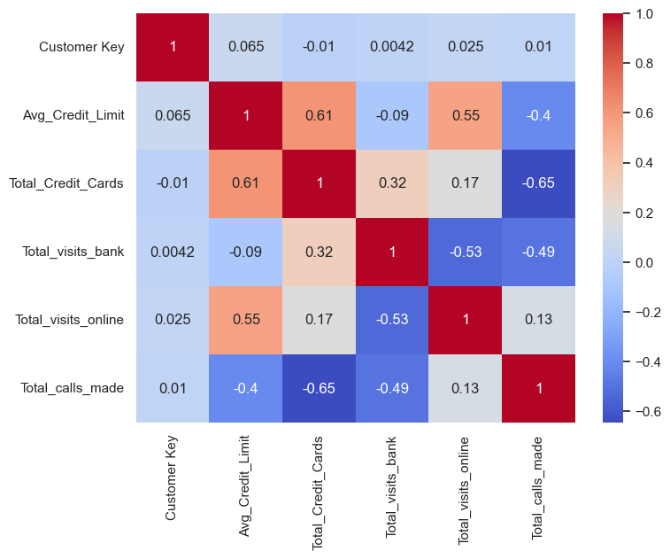

```python
# Select only numeric columns
numeric_df = df.select_dtypes(include=[np.number])

# Calculate correlation
correlation_matrix = numeric_df.corr()

print(correlation_matrix)

plt.figure(figsize=(8,6))
sns.heatmap(correlation_matrix, annot=True,cmap='coolwarm')
```

Key Insights:

- Avg_Credit_Limit: There is a strong positive correlation between average credit limit and total credit cards. This suggests that customers with more credit cards tend to have higher credit limits.

  ```
                There is a moderate positive correlation between average credit limit and total online visits, implying that customers with higher credit limits may engage more through online services.
                There is a moderate negative correlation between average credit limit and total calls made. This suggests that customers with higher credit limits tend to make fewer calls to the bank.
  ```

- Total_Credit_Cards: There is a moderate positive correlation between total credit cards and total bank visits, implying that customers with more credit cards visit the bank more frequently.

  ```
                  There is a strong negative correlation between total credit cards and total calls made. This suggests that customers with more credit cards tend to make fewer calls, possibly because they are more self-sufficient or use other channels like online services.
  ```

  ```
                 There is a moderate negative correlation between bank visits and total calls made, implying that customers who visit the bank more frequently tend to make fewer calls.
  ```

**Summary:**

Higher credit limits are associated with more credit cards and more online engagement but fewer calls to customer support.

Customers who make more bank visits tend to make fewer online visits and fewer calls, possibly indicating a preference for in-person interactions.

Customers with more credit cards tend to make fewer calls and may rely on online services more frequently.

These insights can help the bank identify customer behavior patterns, inform strategies for improving customer service, and tailor marketing campaigns to different segments based on their engagement with the bank.

#### **Scaling the data**

```python
# Scaling the data before clustering. It is performed on all the numerical features in the dataset.
# df.iloc[:,:6] selects all rows and columns starting from the 0 to 5th column.
# copy()ensures that you're working with a separate copy of this subset of data, not just a reference to the original DataFrame.

scaler = StandardScaler()
subset = df.iloc[:,:6].copy()
subset_scaled = scaler.fit_transform(subset)
```

```python
subset_scaled
```

```
array([[-1.71151193,  0.44611612,  1.0617926 ,  0.34926885, -0.21216514,
        -1.25918169],
       [-1.70631407, -0.60218084,  0.59999037,  1.5565042 , -0.21216514,
        -0.91044427],
       [-1.70576692, -0.41402497, -1.24721853, -0.25434882,  0.12678161,
         0.135768  ],
       ...,
       [ 1.74034183, -0.38714556, -1.24721853, -0.25434882,  0.46572835,
         1.5307177 ],
       [ 1.7406154 , -0.46778379, -1.70902076, -1.46158417,  0.80467509,
         0.48450543],
       [ 1.75026859,  2.38143357,  1.52359483, -0.8579665 ,  4.19414251,
        -0.56170684]])
```

```python
# Creating a dataframe of the scaled data
subset_scaled_df = pd.DataFrame(subset_scaled, columns = subset.columns)
```

```python
print("subset_scaled_df is the the scaled data")
subset_scaled_df
```

```
subset_scaled_df is the the scaled data
```

|  | Customer Key | Avg_Credit_Limit | Total_Credit_Cards | Total_visits_bank | Total_visits_online | Total_calls_made |
| --- | --- | --- | --- | --- | --- | --- |
| 0 | -1.711512 | 0.446116 | 1.061793 | 0.349269 | -0.212165 | -1.259182 |
| 1 | -1.706314 | -0.602181 | 0.599990 | 1.556504 | -0.212165 | -0.910444 |
| 2 | -1.705767 | -0.414025 | -1.247219 | -0.254349 | 0.126782 | 0.135768 |
| 3 | -1.703657 | -0.682819 | 1.061793 | 1.556504 | -0.890059 | -1.259182 |
| 4 | -1.699905 | 0.096684 | -0.323614 | 0.349269 | -0.212165 | -1.259182 |
| ... | ... | ... | ... | ... | ... | ... |
| 650 | 1.734401 | 0.123563 | 0.599990 | 0.952887 | -0.890059 | 0.135768 |
| 651 | 1.735808 | 0.526754 | 0.138188 | 0.952887 | -0.212165 | -0.910444 |
| 652 | 1.740342 | -0.387146 | -1.247219 | -0.254349 | 0.465728 | 1.530718 |
| 653 | 1.740615 | -0.467784 | -1.709021 | -1.461584 | 0.804675 | 0.484505 |
| 654 | 1.750269 | 2.381434 | 1.523595 | -0.857966 | 4.194143 | -0.561707 |

655 rows × 6 columns

#### **Applying PCA on scaled data**

```python
# Importing PCA
from sklearn.decomposition import PCA

# Defining the number of principal components to generate
n = subset.shape[1]                                                 # Storing the number of variables in the data

pca = PCA(n_components = n, random_state = 1)                       # Storing PCA function with n components

data_pca = pd.DataFrame(pca.fit_transform(subset_scaled_df ))       # Applying PCA on scaled data

# Renaming the columns of the PCA DataFrame
data_pca.columns = [f'PC{i+1}' for i in range(data_pca.shape[1])]

# The percentage of variance explained by each principal component is stored
exp_var = (pca.explained_variance_ratio_)
```

```python
print("data_pca is the  PCA scaled data")
data_pca
```

```
data_pca is the  PCA scaled data
```

|  | PC1 | PC2 | PC3 | PC4 | PC5 | PC6 |
| --- | --- | --- | --- | --- | --- | --- |
| 0 | 1.595878 | -0.508860 | -1.742633 | -0.383364 | 0.116178 | -0.072378 |
| 1 | 0.952481 | -1.566507 | -1.659624 | 0.524168 | -0.287826 | -0.676488 |
| 2 | -1.115345 | -0.024920 | -1.663685 | -0.224722 | -0.820163 | -0.013473 |
| 3 | 1.306859 | -2.117598 | -1.659067 | 0.150301 | 0.175768 | -0.546307 |
| 4 | 0.594865 | -0.688119 | -1.670789 | -0.635741 | -0.852597 | -0.079328 |
| ... | ... | ... | ... | ... | ... | ... |
| 650 | 0.546301 | -0.960484 | 1.794585 | 0.486277 | 0.498453 | 0.419053 |
| 651 | 1.124359 | -0.598472 | 1.777766 | -0.009357 | -0.550480 | 0.074777 |
| 652 | -1.772855 | 0.705086 | 1.781327 | 0.674819 | -0.287041 | 0.088644 |
| 653 | -1.810970 | 1.345975 | 1.699971 | -0.769589 | -0.682081 | -0.386166 |
| 654 | 2.655317 | 4.256403 | 1.480060 | 0.793230 | -0.602998 | -1.160772 |

655 rows × 6 columns

**Observation:**

- The transformed scaled PCA data represents the first six principal components (PC1 to PC6) after applying Principal Component Analysis (PCA) on the scaled dataset.
- Each row corresponds to a data point (a customer, for example), and each column represents one of the principal components (PC1 to PC6). The values in each cell represent the projection of that data point on the corresponding principal component axis.
- PC1, PC2, PC3, etc. are the new axes created by PCA. These axes are linear combinations of the original features and are ordered in terms of the amount of variance they explain. PC1 explains the most variance in the dataset, followed by PC2, and so on.

For instance, data points with a high positive or negative value in PC1 indicate that those points contribute significantly to the most important direction of variance in your dataset.

**We can also visualize the data in 2 dimensions, using the first two principal components.**

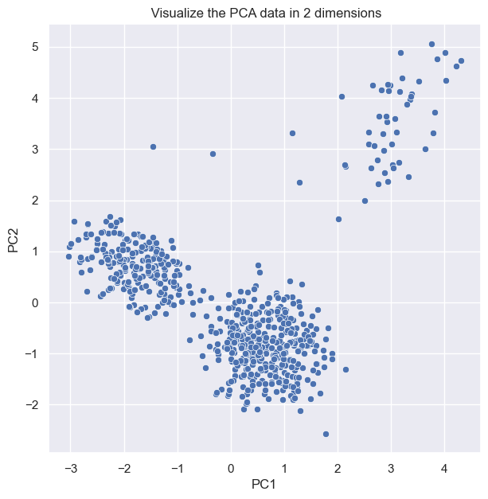

```python
plt.figure(figsize = (7,7))

sns.scatterplot(x = data_pca['PC1'], y = data_pca['PC2'])

plt.title(" Visualize the PCA data in 2 dimensions")

plt.xlabel("PC1")

plt.ylabel("PC2")

plt.show()
```

**Interpretation of the PCA 2D Scatter Plot:**

The scatter plot visualizes the PCA-transformed data in two dimensions using the first two principal components (PC1 and PC2).

1) Data Distribution: The data points are spread across the PC1 and PC2 axes, which represent the directions that capture the most variance in the dataset. The points seem to form three distinct clusters or groups, suggesting natural groupings or segments in the data.

3) Potential for Clustering: The clear separation of data points into clusters suggests that the PCA transformation has successfully captured the underlying structure of the data. This visualization is ideal for applying clustering algorithms like K-Means, GMM, or K-Medoids. Each algorithm would likely identify these visible clusters.

4) Principal Component Contributions: PC1 (horizontal axis) captures the most variance in the data, with PC2 (vertical axis) capturing the second most. The variance explained by these two components likely highlights important features of your dataset, such as customer spending patterns, credit limits, or the number of credit cards, which differentiate customers across these dimensions.

```python
# Get the principal components (loadings or coefficients)
loadings = pca.components_.T * np.sqrt(pca.explained_variance_)
loadings_df = pd.DataFrame(loadings, index=subset.columns, columns=[f'PC{i+1}' for i in range(loadings.shape[1])])

# View the loadings
print(loadings_df)
```

```
                          PC1       PC2       PC3       PC4       PC5       PC6
Customer Key         0.028637  0.068607  0.997303 -0.016952  0.021620 -0.025193
Avg_Credit_Limit     0.740609  0.551801  0.018659  0.026586 -0.125189  0.363065
Total_Credit_Cards   0.904677  0.037694 -0.048276  0.099980  0.401706 -0.089299
Total_visits_bank    0.426274 -0.790666  0.056833  0.394890 -0.187968 -0.012878
Total_visits_online  0.169993  0.907203 -0.041739  0.197119 -0.172518 -0.281519
Total_calls_made    -0.838190  0.312474  0.018893  0.371627  0.193112  0.159910
```

**Observations from the Coefficient Values of the PCA columns:**

- PC1: Primarily captures the relationship between Avg_Credit_Limit, Total_Credit_Cards, and Total_calls_made. Customers with more credit cards and higher credit limits load positively, while those who make more calls load negatively. This component likely reflects overall customer value or engagement.
- PC2: Captures a contrast between online vs. in-person engagement, with Total_visits_online and Avg_Credit_Limit loading positively and Total_visits_bank loading negatively. This reflects a channel preference axis, distinguishing customers based on their mode of interaction with the bank.
- PC3: Dominated by Customer Key, this component does not provide meaningful insights for customer segmentation.
- PC4: Captures service engagement, with Total_visits_bank and Total_calls_made loading positively. It likely reflects how customers interact with the bank’s support services (either in-person or via phone).
- PC5 and PC6: These components capture finer details in the data, showing small differences in credit card ownership and online engagement.**

**Overall Conclusion:**

PC1 and PC2 are the most important components for explaining variance in customer behavior, capturing customer value and interaction preferences (online vs. in-person).

PC4 also captures useful information related to support engagement (visits and calls), while the remaining components provide more nuanced or minor distinctions.

These insights could guide the bank’s segmentation and personalization efforts, helping them identify high-value customers, understand channel preferences, and tailor services accordingly.

```python
exp_var
```

```
array([0.37957477, 0.30893147, 0.16684827, 0.05722765, 0.04657774,
       0.04084009])
```

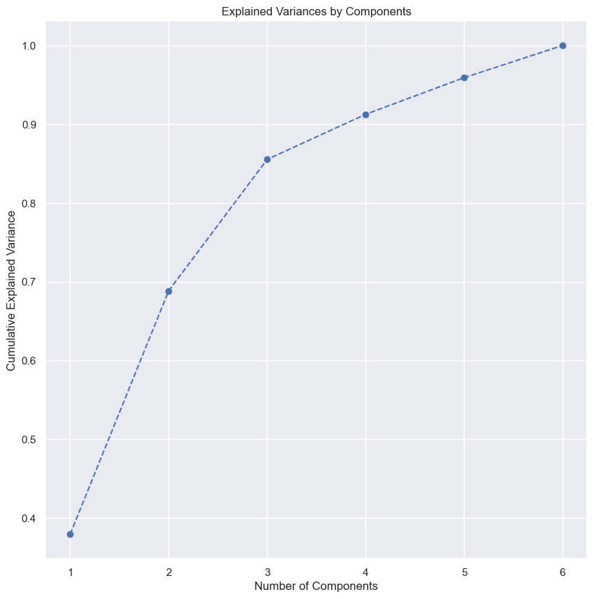

```python
# Plotting the explained cumulative variance by principal components
plt.figure(figsize = (10, 10))

plt.plot(range(1, len(exp_var) + 1), pca.explained_variance_ratio_.cumsum(), marker = 'o', linestyle = '--')

plt.title("Explained Variances by Components")

plt.xlabel("Number of Components")

plt.ylabel("Cumulative Explained Variance")

plt.show()
```

**Inference:**

**Conclusion:**

- The plot suggests that using the first 2 to 3 components would be sufficient to capture most of the variance in your dataset, making it possible to reduce the dimensionality without sacrificing too much valuable information.

## **K-Means**

Let us now fit the K-means algorithm on our pca components and find out the optimum number of clusters to use.

We will do this in 3 steps:

1. Initialize a dictionary to store the Sum of Squared Error (SSE) for each K
2. Run for a range of Ks and store SSE for each run
3. Plot the SSE vs K and plot the elbow curve

K-Means clustering is one of the most popular clustering algorithms used for partitioning a dataset into K clusters. The algorithm works by iteratively assigning each data point to one of the K clusters based on the proximity of the data points to the centroids of the clusters. K-Means clustering is a computationally efficient algorithm that can work well even for datasets with a large number of variables.

The steps involved in K-Means clustering are as follows:

Choose the number of clusters K that you want to partition the data into.

Initialize the K centroids randomly.

Assign each data point to the nearest centroid.

Recalculate the centroids of each cluster as the mean of all the data points assigned to it.

Repeat steps 3 and 4 until the centroids no longer change or a maximum number of iterations is reached.

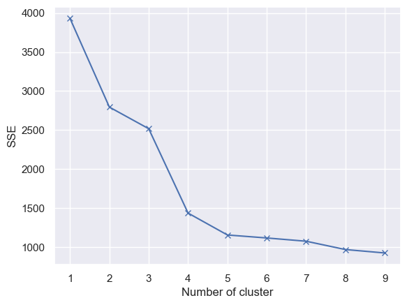

```python
# Empty dictionary to store the SSE for each value of K
sse = {}

# Iterate for a range of Ks and fit the scaled data to the algorithm.
# Use inertia attribute from the clustering object and store the inertia value for that K
for k in range(1, 10):
    kmeans = KMeans(n_clusters = k, random_state = 1).fit(data_pca)

    sse[k] = kmeans.inertia_

# Elbow plot
plt.figure()

plt.plot(list(sse.keys()), list(sse.values()), 'bx-')

plt.xlabel("Number of cluster")

plt.ylabel("SSE")

plt.show()
```

**Observations:**

- From the plot, you can see that the SSE decreases sharply between 1 and 4 clusters, but after 4, the rate of decrease slows down.
- The elbow is typically at the point where the line starts to bend and flatten out. In this plot, the elbow appears to be around k = 4. After this point, adding more clusters does not significantly reduce the SSE.
- Interpret the above elbow plot and state the reason for choosing the particular value of K
- Fit the K-means algorithms on the pca components with the number of clusters for the chosen value of K

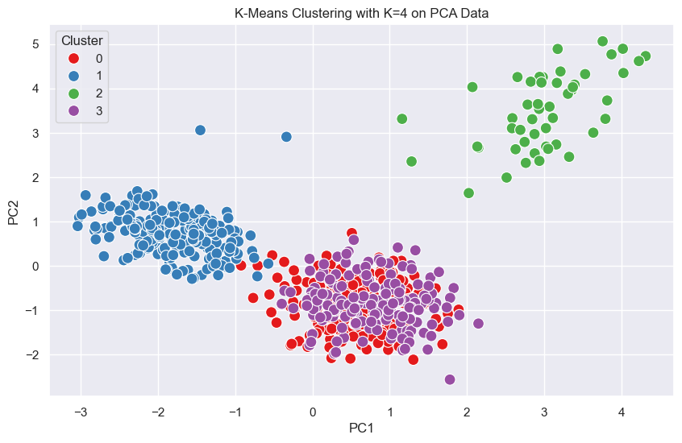

```python
# 'data_pca' is the dataframe with PCA-transformed components (e.g., PC1, PC2, PC3)

# Step 1: Fit K-Means with k=4
kmeans = KMeans(n_clusters=4, random_state=42)
kmeans.fit(data_pca)

# Step 2: Get the cluster labels for each data point
cluster_labels = kmeans.labels_

# Step 3: Add the cluster labels to the PCA data for visualization or analysis
data_pca['Cluster'] = cluster_labels

# Step 4: Visualize the clustering (e.g., with PC1 and PC2)

plt.figure(figsize=(10,6))
sns.scatterplot(x=data_pca['PC1'], y=data_pca['PC2'], hue=data_pca['Cluster'], palette='Set1', s=100)
plt.title('K-Means Clustering with K=4 on PCA Data')
plt.show()
```

**Observation:**

This scatter plot shows the results of applying K-Means clustering with 4 clusters (K=4) to the PCA-transformed data, visualized along the first two principal components, PC1 and PC2.

Each point represents a data point (such as a customer), and the color indicates the cluster it belongs to.

The 4 clusters in this plot represent 4 different customer segments based on the PCA-transformed data.

This visualization can help identify customer segments and tailor marketing strategies or service offerings based on the characteristics of each cluster.

#### **Create the cluster profiles using the summary statistics and box plots for each label**

```python
# Creating copy of the data to store labels from each algorithm
data_scaled_copy = data_pca.copy(deep = True)
```

```python
data_scaled_copy
```

|  | PC1 | PC2 | PC3 | PC4 | PC5 | PC6 | Cluster |
| --- | --- | --- | --- | --- | --- | --- | --- |
| 0 | 1.595878 | -0.508860 | -1.742633 | -0.383364 | 0.116178 | -0.072378 | 0 |
| 1 | 0.952481 | -1.566507 | -1.659624 | 0.524168 | -0.287826 | -0.676488 | 0 |
| 2 | -1.115345 | -0.024920 | -1.663685 | -0.224722 | -0.820163 | -0.013473 | 1 |
| 3 | 1.306859 | -2.117598 | -1.659067 | 0.150301 | 0.175768 | -0.546307 | 0 |
| 4 | 0.594865 | -0.688119 | -1.670789 | -0.635741 | -0.852597 | -0.079328 | 0 |
| ... | ... | ... | ... | ... | ... | ... | ... |
| 650 | 0.546301 | -0.960484 | 1.794585 | 0.486277 | 0.498453 | 0.419053 | 3 |
| 651 | 1.124359 | -0.598472 | 1.777766 | -0.009357 | -0.550480 | 0.074777 | 3 |
| 652 | -1.772855 | 0.705086 | 1.781327 | 0.674819 | -0.287041 | 0.088644 | 1 |
| 653 | -1.810970 | 1.345975 | 1.699971 | -0.769589 | -0.682081 | -0.386166 | 1 |
| 654 | 2.655317 | 4.256403 | 1.480060 | 0.793230 | -0.602998 | -1.160772 | 2 |

655 rows × 7 columns

```python
kmeans = KMeans(n_clusters = 4, random_state = 1)

kmeans.fit(data_pca)

# Adding predicted labels to the original data and the scaled data and assigning it to data_scaled_copy
data_scaled_copy['KMeans_Labels'] = kmeans.predict(data_pca)

df['KMeans_Labels'] = kmeans.predict(data_pca)
```

```python
df
```

|  | Customer Key | Avg_Credit_Limit | Total_Credit_Cards | Total_visits_bank | Total_visits_online | Total_calls_made | KMeans_Labels |
| --- | --- | --- | --- | --- | --- | --- | --- |
| 0 | 11265 | 51000.0 | 7 | 3 | 2 | 0 | 0 |
| 1 | 11398 | 12000.0 | 6 | 5 | 2 | 1 | 0 |
| 2 | 11412 | 19000.0 | 2 | 2 | 3 | 4 | 1 |
| 3 | 11466 | 9000.0 | 7 | 5 | 0 | 0 | 0 |
| 4 | 11562 | 38000.0 | 4 | 3 | 2 | 0 | 0 |
| ... | ... | ... | ... | ... | ... | ... | ... |
| 650 | 99437 | 39000.0 | 6 | 4 | 0 | 4 | 3 |
| 651 | 99473 | 54000.0 | 5 | 4 | 2 | 1 | 3 |
| 652 | 99589 | 20000.0 | 2 | 2 | 4 | 8 | 1 |
| 653 | 99596 | 17000.0 | 1 | 0 | 5 | 5 | 1 |
| 654 | 99843 | 123000.0 | 8 | 1 | 15 | 2 | 2 |

655 rows × 7 columns

```python
print ("pca scaled data")
data_scaled_copy
```

```
pca scaled data
```

|  | PC1 | PC2 | PC3 | PC4 | PC5 | PC6 | Cluster | KMeans_Labels |
| --- | --- | --- | --- | --- | --- | --- | --- | --- |
| 0 | 1.595878 | -0.508860 | -1.742633 | -0.383364 | 0.116178 | -0.072378 | 0 | 0 |
| 1 | 0.952481 | -1.566507 | -1.659624 | 0.524168 | -0.287826 | -0.676488 | 0 | 0 |
| 2 | -1.115345 | -0.024920 | -1.663685 | -0.224722 | -0.820163 | -0.013473 | 1 | 1 |
| 3 | 1.306859 | -2.117598 | -1.659067 | 0.150301 | 0.175768 | -0.546307 | 0 | 0 |
| 4 | 0.594865 | -0.688119 | -1.670789 | -0.635741 | -0.852597 | -0.079328 | 0 | 0 |
| ... | ... | ... | ... | ... | ... | ... | ... | ... |
| 650 | 0.546301 | -0.960484 | 1.794585 | 0.486277 | 0.498453 | 0.419053 | 3 | 3 |
| 651 | 1.124359 | -0.598472 | 1.777766 | -0.009357 | -0.550480 | 0.074777 | 3 | 3 |
| 652 | -1.772855 | 0.705086 | 1.781327 | 0.674819 | -0.287041 | 0.088644 | 1 | 1 |
| 653 | -1.810970 | 1.345975 | 1.699971 | -0.769589 | -0.682081 | -0.386166 | 1 | 1 |
| 654 | 2.655317 | 4.256403 | 1.480060 | 0.793230 | -0.602998 | -1.160772 | 2 | 2 |

655 rows × 8 columns

```python
df['KMeans_Labels'].value_counts()
```

```
KMeans_Labels
1    221
0    211
3    174
2     49
Name: count, dtype: int64
```

**Observation**

The output represents the number of data points (or customers) assigned to each cluster by the K-Means algorithm.

**Key Insights:**

Cluster Distribution: The data points are not evenly distributed across the clusters. Clusters 1 and 0 have the majority of the data points, while Cluster 2 has significantly fewer.

Cluster Size: Cluster 2 may represent a small but distinct group of customers with characteristics different from the larger clusters (e.g., niche or unique customer behavior).

Imbalance: The fact that one cluster (Cluster 2) is much smaller could indicate that this cluster captures an outlier group or a more specific segment of customers, while the larger clusters (Clusters 1, 0, and 3) capture more common customer profiles.

```python
# Step 1: Check the columns to identify the add on columns
print(df.columns)
```

```
Index(['Customer Key', 'Avg_Credit_Limit', 'Total_Credit_Cards',
       'Total_visits_bank', 'Total_visits_online', 'Total_calls_made',
       'KMeans_Labels'],
      dtype='object')
```

```python
# Calculating the mean,median,std,min and max of the original data for each label

num_cols = df.select_dtypes(include = "number").columns.to_list()

mean = df[num_cols].groupby('KMeans_Labels').mean()

median = df[num_cols].groupby('KMeans_Labels').median()

std = df[num_cols].groupby('KMeans_Labels').std()

min = df[num_cols].groupby('KMeans_Labels').min()

max = df[num_cols].groupby('KMeans_Labels').max()

df_kmeans = pd.concat([mean, median, std, min, max ], axis = 0)

df_kmeans.index = ['cluster_0 Mean', 'cluster_1 Mean', 'cluster_2 Mean', 'cluster_3 Mean','cluster_0 Median', 'cluster_1 Median', 'cluster_2 Median','cluster_2 Median','cluster_0 std', 'cluster_1 std', 'cluster_2 std', 'cluster_3 std','cluster_0 min', 'cluster_1 min', 'cluster_2 min','cluster_3 min','cluster_0 max', 'cluster_1 max', 'cluster_2 max','cluster_3 max']

df_kmeans.T
```

|  | cluster_0 Mean | cluster_1 Mean | cluster_2 Mean | cluster_3 Mean | cluster_0 Median | cluster_1 Median | cluster_2 Median | cluster_2 Median | cluster_0 std | cluster_1 std | cluster_2 std | cluster_3 std | cluster_0 min | cluster_1 min | cluster_2 min | cluster_3 min | cluster_0 max | cluster_1 max | cluster_2 max | cluster_3 max |
| --- | --- | --- | --- | --- | --- | --- | --- | --- | --- | --- | --- | --- | --- | --- | --- | --- | --- | --- | --- | --- |
| Customer Key | 34803.616114 | 55663.276018 | 55867.408163 | 78623.241379 | 35549.0 | 55849.0 | 53834.0 | 78765.0 | 13380.880960 | 25888.824574 | 26466.503593 | 12461.598123 | 11265.0 | 11412.0 | 13315.0 | 50706.0 | 58708.0 | 99596.0 | 99843.0 | 99473.0 |
| Avg_Credit_Limit | 30549.763033 | 12658.371041 | 139255.102041 | 37166.666667 | 26000.0 | 12000.0 | 145000.0 | 36000.0 | 21093.694328 | 8099.230326 | 35660.453477 | 22808.598757 | 5000.0 | 3000.0 | 58500.0 | 5000.0 | 75000.0 | 102000.0 | 200000.0 | 100000.0 |
| Total_Credit_Cards | 5.407583 | 2.407240 | 8.775510 | 5.609195 | 5.0 | 2.0 | 9.0 | 6.0 | 1.160763 | 1.110586 | 1.262691 | 1.115900 | 3.0 | 1.0 | 5.0 | 2.0 | 7.0 | 5.0 | 10.0 | 7.0 |
| Total_visits_bank | 3.393365 | 0.945701 | 0.653061 | 3.614943 | 3.0 | 1.0 | 1.0 | 4.0 | 1.159537 | 0.807207 | 0.596902 | 1.256661 | 0.0 | 0.0 | 0.0 | 1.0 | 5.0 | 2.0 | 3.0 | 10.0 |
| Total_visits_online | 1.028436 | 3.606335 | 11.000000 | 0.959770 | 1.0 | 4.0 | 11.0 | 1.0 | 0.861420 | 1.255445 | 2.865019 | 0.882451 | 0.0 | 1.0 | 6.0 | 0.0 | 4.0 | 10.0 | 15.0 | 2.0 |
| Total_calls_made | 2.052133 | 6.932127 | 1.102041 | 1.988506 | 2.0 | 7.0 | 1.0 | 2.0 | 1.431660 | 1.953996 | 0.871897 | 1.446497 | 0.0 | 2.0 | 0.0 | 0.0 | 4.0 | 10.0 | 3.0 | 4.0 |

**Cluster Profiles:**

Cluster Profiles Based on These Stats:

- Cluster 0: It consists of early customers who prefer in-person banking with moderate credit card usage. They rely less on online services but engage moderately through phone calls.
- Cluster 1: It consists of low-value customers with fewer credit cards and minimal in-person engagement. However, they rely heavily on phone support and use online services more than in-person banking.
- Cluster 2: It represents high-value customers who have high credit limits and multiple credit cards but prefer online banking and rarely visit the bank or make phone calls.
- Cluster 3: It represents the most recent customers who prefer in-person banking but are moderately engaged in credit products. They rely slightly on phone support but have minimal online activity.

**Overall Summary:**

- Cluster 0: Early customers, moderate credit card usage, and prefer in-person banking.
- Cluster 1: Low-value customers with few credit cards, relying heavily on phone support and moderate online engagement.
- Cluster 2: High-value customers with high credit limits and multiple credit cards, preferring online banking with minimal in-person or phone engagement.
- Cluster 3: Recent customers, moderate credit card usage, preferring in-person visits, and moderate reliance on phone support.

These insights highlight each cluster's preferences and behaviors, allowing the bank to tailor its services and engagement strategies to better serve the needs of each group.

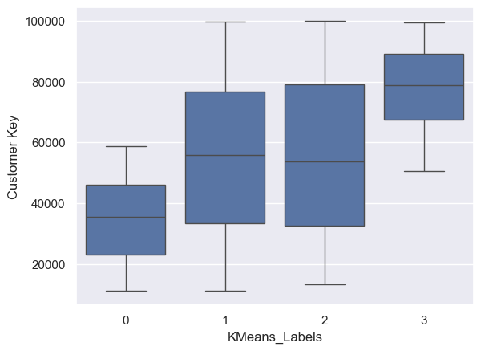

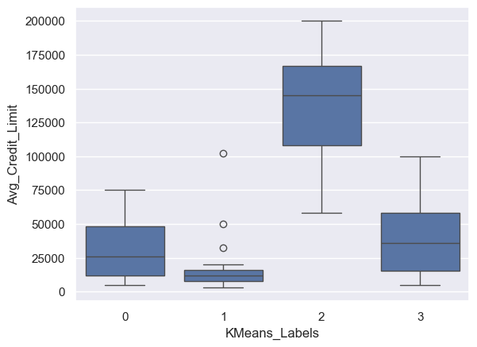

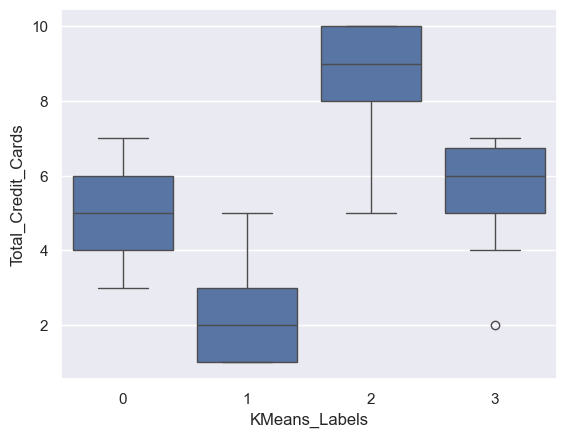

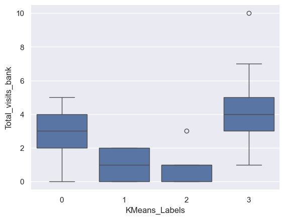

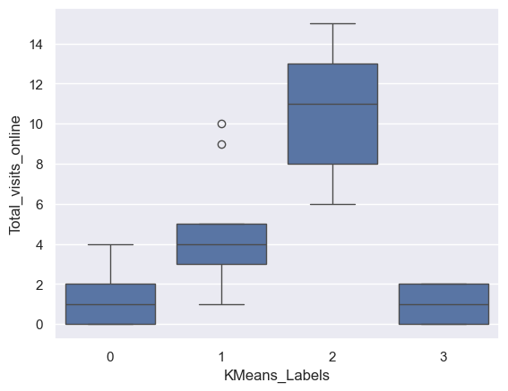

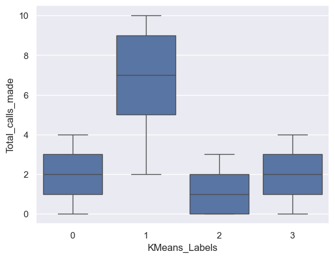

```python
# boxplot representation :

cols_visualise =['Customer Key',  'Avg_Credit_Limit',  'Total_Credit_Cards',  'Total_visits_bank',  'Total_visits_online',  'Total_calls_made']
for col in cols_visualise:
    sns.boxplot(x = 'KMeans_Labels', y = col, data = df)
    plt.show()
```